# AMultinational Bank Customer Churn

### Does churn depends on different banking product and services provide by the banks?

Chi Square Test for independence

H0: Banking products, services and churn are independent

H1: Banking products, services and churn are not independent

```r
#Contingency table
contab_productnumber = table(churn_data$churn, churn_data$products_number)
xkabledply(contab_productnumber, title="Contingency table for Banking Services vs Churn (0 or 1)")

#Chisquare Test of independency
chitests = chisq.test(contab_productnumber)
chitests

chitests$statistic
chitests$parameter
```

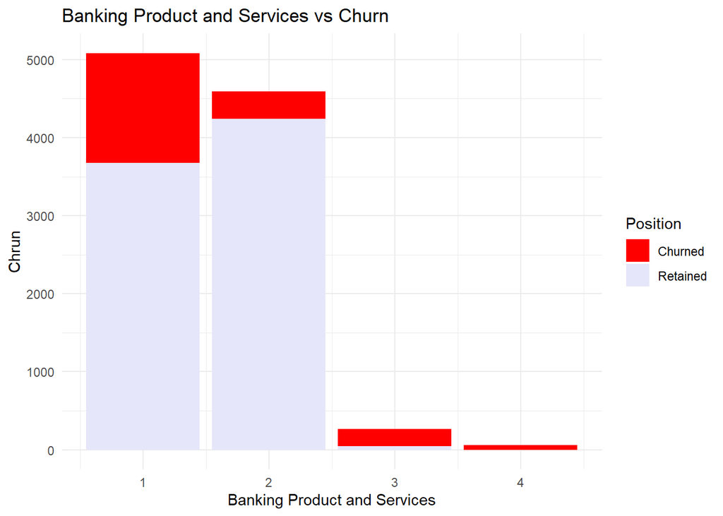

```r
ggplot(data=churn_data,aes(x=products_number,fill=churn))+
  geom_bar()+
  scale_fill_manual('Position', values=c('red', 'lavender')) +
  labs(title = "Banking Product and Services vs Churn",x="Banking Product and Services",y="Chrun")+
  theme_minimal()
```

We can notice that most of the customers with lower and higher products i.e) 1, 3 and 4 are about to churned when compared to customers with two products.

### Does churn depend on status of active account users?

Chi Square Test for independence

H0: Customer’s active status and churn are independent

H1: Customer’s active status and churn are not independent

```r
#Contingency table
contab_activemember = table(churn_data$churn, churn_data$active_member)
xkabledply(contab_activemember, title="Contingency table for Account Status(Active, In Active) vs Churn (0 or 1)")

#Chisquare Test of independency
chitests = chisq.test(contab_activemember)
chitests

chitests$statistic
chitests$parameter
chitests$p.value
```

We have the $\chi^2$ value of the test from `chitests$statistic` = 242.985, while the p-value is less than the significance level of 0.05 from `chitests$p.value` = 8.786^{-55}. As a result, we reject the null hypothesis H0 and find that the churn rate is reliant on the customer’s banking services.

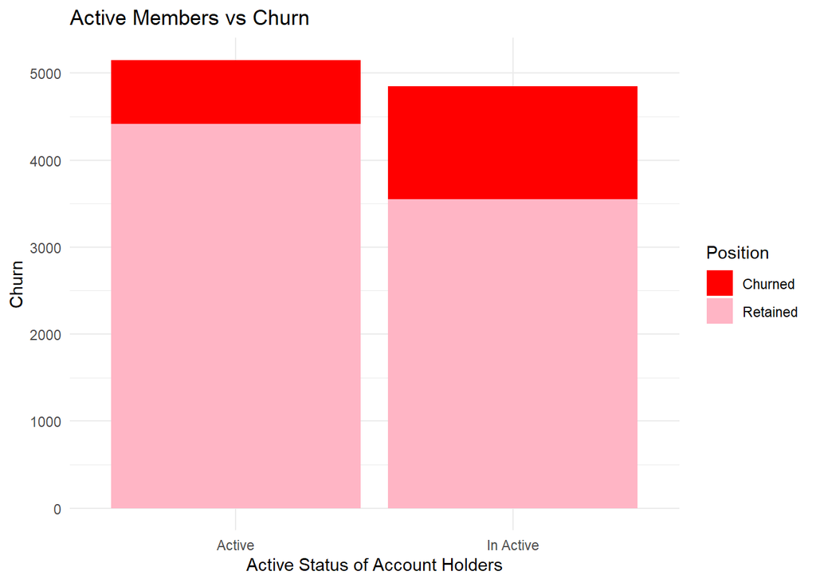

```r
ggplot(data=churn_data,aes(x=active_member,fill=churn))+
  geom_bar()+
  scale_fill_manual('Position', values=c('red', 'pink1')) +
  labs(title = "Active Members vs Churn",x="Active Status of Account Holders",y="Churn")+
  theme_minimal()
```

### Does a higher/lower account balance of the customer affect churn?

Correlation test between account balance and churn

```r
library(corrplot)
churn_data_to_numeric <- churn_data
churn_data_to_numeric$churn <- as.numeric(churn_data_to_numeric$churn)

churn_data_numeric <- select_if(churn_data_to_numeric, is.numeric)

cors_bal <- cor(churn_data_numeric)
corrplot(cors_bal, method = 'number')
```

```r
cor_balance<-cor.test(churn_data$balance,as.numeric(churn_data$churn), method="pearson")
cor_balance
```

Customer churn is weakly correlated with account balance with a score of 0.12 For further analysis we can check the correlation score by combining multiple variables

```r
loadPkg("BSDA")

ttestbalances95 = t.test(churn_balance_sample$credit_score) # default conf.level = 0.95
ttestbalances95
ttestbalances99 = t.test(churn_balance_sample$credit_score, conf.level=0.99 )
ttestbalances99
ttestbalances50 = t.test(churn_balance_sample$credit_score,  conf.level=0.50 )
ttestbalances50

ttestbalances95$conf.int
ttestbalances99$conf.int
ttestbalances50$conf.int
```

### Does a higher/lower credit score of the customer affect churn?

Correlation test between credit score and churn

```r
library(corrplot)
churn_data_to_numeric <- churn_data

churn_data$churn[churn_data$churn== "Churned"]<-1
churn_data$churn[churn_data$churn== "Retained"]<-0


churn_data_to_numeric$churn <- as.numeric(churn_data_to_numeric$churn)
str(churn_data_to_numeric)
churn_data_numeric <- select_if(churn_data_to_numeric, is.numeric)
str(churn_data_numeric)
cors_credit <- cor(churn_data_numeric)
corrplot(cors_credit, method = 'number')
```

```r
cor_scores <- cor(churn_data_numeric$credit_score, churn_data_numeric$churn)
cor_scores
```

**The credit score is weakly correlated with customer churn with a score of -0.0271**

### Does churn depend on age of the customers?

```r
library(corrplot)
churn_data_to_numeric <- churn_data

churn_data$churn[churn_data$churn== "Churned"]<-1
churn_data$churn[churn_data$churn== "Retained"]<-0


churn_data_to_numeric$churn <- as.numeric(churn_data_to_numeric$churn)
str(churn_data_to_numeric)
churn_data_numeric <- select_if(churn_data_to_numeric, is.numeric)
str(churn_data_numeric)
cors_age_group <- cor(churn_data_numeric)
corrplot(cors_age_group, method = 'number')
```

```r
cor_age <- cor(churn_data_numeric$age, churn_data_numeric$churn)
cor_age
```

```r
loadPkg("BSDA")

ttestage95 = t.test(churn_balance_sample$age) # default conf.level = 0.95
ttestage95
ttestage99 = t.test(churn_balance_sample$age, conf.level=0.99 )
ttestage99
ttestage50 = t.test(churn_balance_sample$age,  conf.level=0.50 )
ttestage50

ttestage95$conf.int
ttestage99$conf.int
ttestage50$conf.int
```

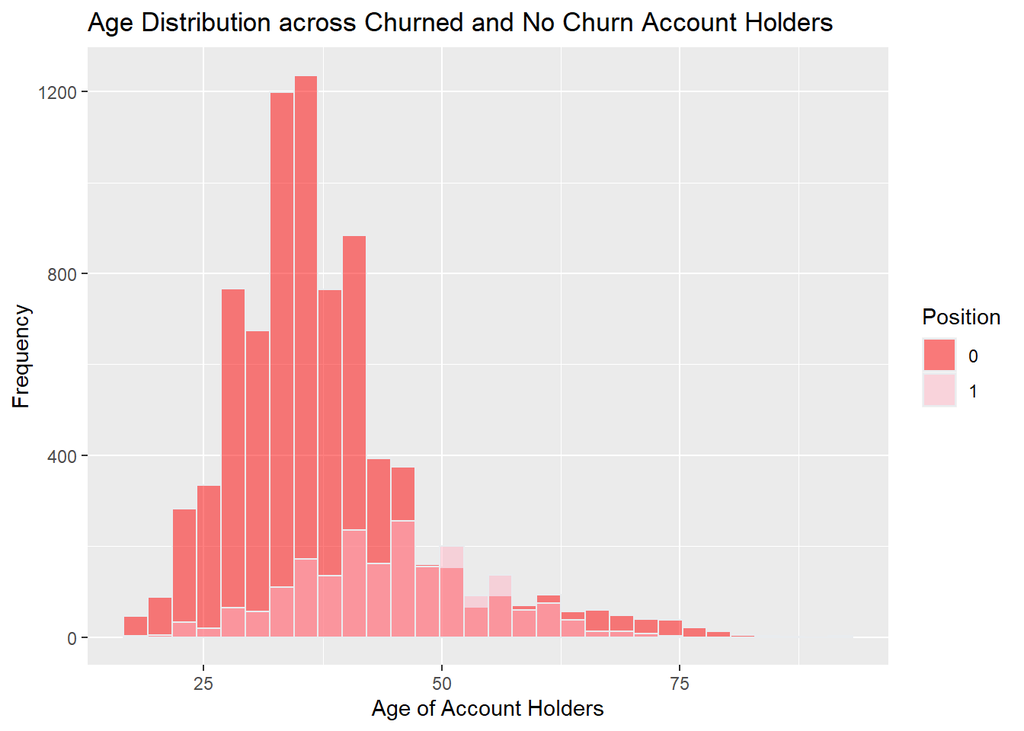

```r
ggplot(churn_data, aes(x=age, fill=churn)) +
  geom_histogram( color='#e9ecef', alpha=0.5, position='identity') + scale_fill_manual('Position', values=c('red', 'pink1')) +
  labs(title = "Age Distribution across Churned and No Churn Account Holders",x="Age of Account Holders",y="Frequency")
```

```r
#Contingency table
churn_age = table(churn_data$churn, churn_data$age)
churn_age

#Chisquare Test of independence
chichurn_age = chisq.test(churn_age)
chichurn_age

chichurn_age$statistic
chichurn_age$parameter
chichurn_age$p.value
```

Churn & Age are about to moderately correlated (Positive) - 0.29.

```r
corr <- cor(churn_data_numeric$age, churn_data_numeric$churn)
corr
```

```
## [1] 0.285
```

```r
corr1 <- cor(churn_data_numeric$age + churn_data_numeric$tenure, churn_data_numeric$churn)
corr1
```

```
## [1] 0.272
```

```r
corr2 <- cor(churn_data_numeric$age + churn_data_numeric$products_number, churn_data_numeric$churn)
corr2
```

```
## [1] 0.283
```

```r
corr3 <- cor(churn_data_numeric$age + churn_data_numeric$balance, churn_data_numeric$churn)
corr3
```

```
## [1] 0.119
```

```r
corr4 <- cor(churn_data_numeric$age + churn_data_numeric$tenure + churn_data_numeric$products_number, churn_data_numeric$churn)
corr4
```

```
## [1] 0.269
```

```r
corr5 <- cor(churn_data_numeric$age + churn_data_numeric$products_number + churn_data_numeric$balance, churn_data_numeric$churn)
corr5
```

```
## [1] 0.119
```

The correlation score is the highest for the age variable. After combining different columns and finding the correlation score we see that it starts decreasing from 0.285

```r
library(ROSE)

sum(churn_data$country == 'France')
```

```
## [1] 5014
```

```r
sum(churn_data$country == 'Germany')
```

```
## [1] 2509
```

```r
sum(churn_data$country == 'Spain')
```

```
## [1] 2477
```

```r
ind <- sample(2, nrow(churn_data), replace = TRUE, prob = c(0.7, 0.3))
train <- churn_data[ind==1,]
test <- churn_data[ind==2,]


data_balanced_over <- ovun.sample(churn ~ ., data = train, method = "over",N = 10000,seed=123)$data
table(data_balanced_over$country)
```

```
##
##  France Germany   Spain
##    4659    3043    2298
```

```r
str(data_balanced_over)
```

```
## 'data.frame':    10000 obs. of  11 variables:
##  $ credit_score    : int  699 684 528 497 476 616 732 636 846 577 ...
##  $ country         : chr  "France" "France" "France" "Spain" ...
##  $ gender          : chr  "Female" "Male" "Male" "Male" ...
##  $ age             : int  39 27 31 24 34 45 41 32 38 25 ...
##  $ tenure          : int  1 2 6 3 10 3 8 8 5 3 ...
##  $ balance         : num  0 134604 102017 0 0 ...
##  $ products_number : int  2 1 2 2 2 2 2 2 1 2 ...
##  $ credit_card     : chr  "No-Credit Card" "Credit Card" "No-Credit Card" "Credit Card" ...
##  $ active_member   : chr  "In Active" "Active" "In Active" "In Active" ...
##  $ estimated_salary: num  93827 71726 80181 76390 26261 ...
##  $ churn           : chr  "0" "0" "0" "0" ...
```

### Model Building and trainig

**Let us see the probability of customer are churned/not churned.**

```r
prop.table( table(churn_data$churn) )
```

we observe that his probability table tells you that around 20 percent of the customers are churned. If those customers are all the ones that are having good relationship with the bank, then the bank is going to face severe strike on its business rate. Let’s use the different modelling methods to train our dataset to see if we can find out what’s causing customers to close the account with the particular bank.

```r
str(churn_data)
churn_data_pc<-data_balanced_over
churn_data_pc$country[churn_data$country == 'France'] <- 0
churn_data_pc$country[churn_data$country == 'Germany'] <- 1
churn_data_pc$country[churn_data$country == 'Spain'] <- 2

churn_data_pc$gender[churn_data$gender == 'Male'] <- 0
churn_data_pc$gender[churn_data$gender == 'Female'] <- 1

churn_data_pc$credit_card[churn_data$credit_card == 'No-Credit Card'] <- 0
churn_data_pc$credit_card[churn_data$credit_card == 'Credit Card'] <- 1

churn_data_pc$active_member[churn_data$active_member == 'In Active'] <- 0
churn_data_pc$active_member[churn_data$active_member == 'Active'] <- 1

churn_data_pc$active_member = as.numeric(churn_data_pc$active_member)
churn_data_pc$credit_card = as.numeric(churn_data_pc$credit_card)
churn_data_pc$country = as.numeric(churn_data_pc$country)
churn_data_pc$gender = as.numeric(churn_data_pc$gender)
churn_data_pc$churn = as.numeric(churn_data_pc$churn)

churn_data_pc_target = churn_data_pc #includes 'churn'
churn_data_logit <- churn_data_pc_target[-c(1)]
churn_data_pc <- churn_data_logit[-c(11)]
str(churn_data_pc)
```

```r
str(churn_data_pc_target)
str(churn_data_pc)
churn_data_scale <- data.frame(scale(churn_data_pc))
xkabledply(cor(churn_data_scale))
xkabledply(cov(churn_data_scale))
```

### Does the combination of variables such as country, age group, gender influence the churn rate?

```r
churnLogit <- glm(churn ~ age + gender + country, data = churn_data_pc_target, family = "binomial")
summary(churnLogit)
```

```
##
## Call:
## glm(formula = churn ~ age + gender + country, family = "binomial",
##     data = churn_data_pc_target)
##
## Deviance Residuals:
##    Min      1Q  Median      3Q     Max
## -2.669  -0.951  -0.697   1.098   2.035
##
## Coefficients:
##             Estimate Std. Error z value Pr(>|z|)
## (Intercept) -3.26823    0.09882  -33.07   <2e-16 ***
## age          0.07493    0.00228   32.90   <2e-16 ***
## gender      -0.06431    0.04332   -1.48     0.14
## country     -0.02775    0.02609   -1.06     0.29
## ---
## Signif. codes:  0 '***' 0.001 '**' 0.01 '*' 0.05 '.' 0.1 ' ' 1
##
## (Dispersion parameter for binomial family taken to be 1)
##
##     Null deviance: 13698  on 9999  degrees of freedom
## Residual deviance: 12391  on 9996  degrees of freedom
## AIC: 12399
##
## Number of Fisher Scoring iterations: 4
```

```r
xkabledply(churnLogit, title = paste("Logistic Regression :", format(formula(churnLogit)) ))
```

Logistic Regression : churn ~ age + gender + country

|  | Estimate | Std. Error | z value | Pr(>\|z\|) |
| --- | --- | --- | --- | --- |
| (Intercept) | -3.2682 | 0.0988 | -33.07 | 0.000 |
| age | 0.0749 | 0.0023 | 32.90 | 0.000 |
| gender | -0.0643 | 0.0433 | -1.48 | 0.138 |
| country | -0.0277 | 0.0261 | -1.06 | 0.287 |

```r
xkabledply( confint(churnLogit), title = "CIs using profiled log-likelihood" )
```

CIs using profiled log-likelihood

|  | 2.5 % | 97.5 % |
| --- | --- | --- |
| (Intercept) | -3.4631 | -3.0757 |
| age | 0.0705 | 0.0794 |
| gender | -0.1493 | 0.0206 |
| country | -0.0789 | 0.0234 |

```r
xkabledply( confint.default(churnLogit), title = "CIs using standard errors" )
```

CIs using standard errors

|  | 2.5 % | 97.5 % |
| --- | --- | --- |
| (Intercept) | -3.4619 | -3.0746 |
| age | 0.0705 | 0.0794 |
| gender | -0.1492 | 0.0206 |
| country | -0.0789 | 0.0234 |

```r
loadPkg("regclass")

xkabledply( confusion_matrix(churnLogit), title = "Confusion matrix from Logit Model" )
```

Confusion matrix from Logit Model

|  | Predicted 0 | Predicted 1 | Total |
| --- | --- | --- | --- |
| Actual 0 | 4705 | 936 | 5641 |
| Actual 1 | 2022 | 2337 | 4359 |
| Total | 6727 | 3273 | 10000 |

```r
unloadPkg("regclass")
```

```r
loadPkg("ResourceSelection")
admitLogitHoslem = hoslem.test(churn_data_pc_target$churn, fitted(churnLogit))
unloadPkg("ResourceSelection")

admitLogitHoslem
```

```
##
##  Hosmer and Lemeshow goodness of fit (GOF) test
##
## data:  churn_data_pc_target$churn, fitted(churnLogit)
## X-squared = 518, df = 8, p-value <2e-16
```

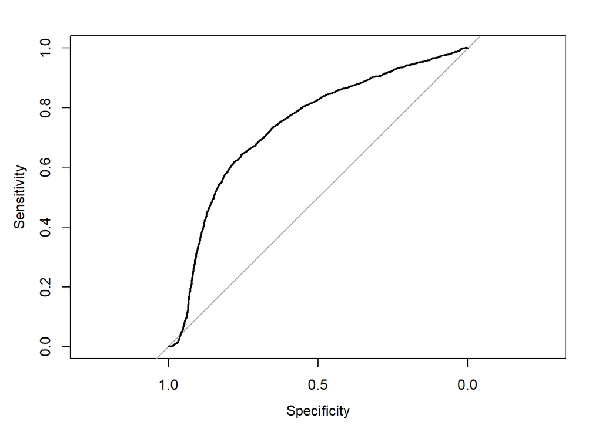

```r
loadPkg("pROC")
prob=predict(churnLogit, type = "response" )
churn_data_pc_target$prob=prob
h <- roc(churn~prob, data=churn_data_pc_target)
auc(h) # area-under-curve prefer 0.8 or higher.
plot(h)
```

```r
# unloadPkg("pROC")
```

```r
unloadPkg("pROC")
```

```r
loadPkg("pscl") # use pR2( ) function to calculate McFadden statistics for model eval
churnLogitpr2 = pR2(churnLogit)
churnLogitpr2
unloadPkg("pscl")
```

### Customers using fewer products along with the status of the account affect the churn rate?

```r
churnLogit_SM2 <- glm(churn ~ products_number + active_member, data = churn_data_pc_target, family = "binomial")
summary(churnLogit_SM2)
```

```
##
## Call:
## glm(formula = churn ~ products_number + active_member, family = "binomial",
##     data = churn_data_pc_target)
##
## Deviance Residuals:
##    Min      1Q  Median      3Q     Max
##  -1.11   -1.08   -1.03    1.27    1.44
##
## Coefficients:
##                 Estimate Std. Error z value Pr(>|z|)
## (Intercept)      -0.1036     0.0551   -1.88     0.06 .
## products_number  -0.1212     0.0308   -3.94  8.3e-05 ***
## active_member     0.0575     0.0404    1.42     0.15
## ---
## Signif. codes:  0 '***' 0.001 '**' 0.01 '*' 0.05 '.' 0.1 ' ' 1
##
## (Dispersion parameter for binomial family taken to be 1)
##
##     Null deviance: 13698  on 9999  degrees of freedom
## Residual deviance: 13680  on 9997  degrees of freedom
## AIC: 13686
##
## Number of Fisher Scoring iterations: 4
```

```r
xkabledply(churnLogit_SM2, title = paste("Logistic Regression :", format(formula(churnLogit_SM2)) ))
```

Logistic Regression : churn ~ products_number + active_member

|  | Estimate | Std. Error | z value | Pr(>\|z\|) |
| --- | --- | --- | --- | --- |
| (Intercept) | -0.1036 | 0.0551 | -1.88 | 0.0602 |
| products_number | -0.1212 | 0.0308 | -3.94 | 0.0001 |
| active_member | 0.0575 | 0.0404 | 1.42 | 0.1546 |

```r
xkabledply( confint(churnLogit_SM2), title = "CIs using profiled log-likelihood" )
```

CIs using profiled log-likelihood

|  | 2.5 % | 97.5 % |
| --- | --- | --- |
| (Intercept) | -0.2117 | 0.0045 |
| products_number | -0.1817 | -0.0610 |
| active_member | -0.0217 | 0.1367 |

```r
xkabledply( confint.default(churnLogit_SM2), title = "CIs using standard errors" )
```

CIs using standard errors

|  | 2.5 % | 97.5 % |
| --- | --- | --- |
| (Intercept) | -0.2117 | 0.0044 |
| products_number | -0.1816 | -0.0609 |
| active_member | -0.0217 | 0.1367 |

```r
loadPkg("regclass")

xkabledply( confusion_matrix(churnLogit_SM2), title = "Confusion matrix from Logit Model" )
```

```
## Predicted levels same as naive model (majority level)
```

Confusion matrix from Logit Model

|  | Predicted 0 |
| --- | --- |
| Actual 0 | 5641 |
| Actual 1 | 4359 |

```r
unloadPkg("regclass")
```

```r
loadPkg("ResourceSelection")
admitLogitHoslem_SM2 = hoslem.test(churn_data_pc_target$churn, fitted(churnLogit_SM2))
unloadPkg("ResourceSelection")
admitLogitHoslem_SM2
```

```
##
##  Hosmer and Lemeshow goodness of fit (GOF) test
##
## data:  churn_data_pc_target$churn, fitted(churnLogit_SM2)
## X-squared = 550, df = 8, p-value <2e-16
```

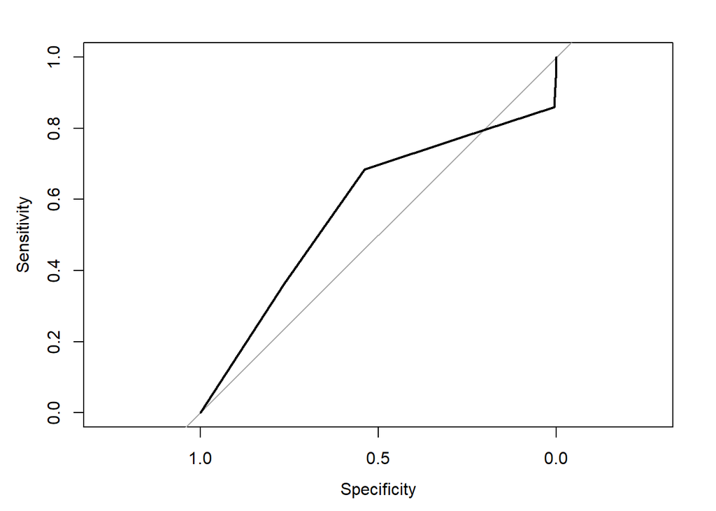

```r
loadPkg("pROC")
prob_SM2 = predict(churnLogit_SM2, type = "response" )
churn_data_pc_target$prob_SM2 = prob_SM2
h_SM2 <- roc(churn~prob_SM2, data=churn_data_pc_target)
auc(h_SM2)
plot(h_SM2)
```

```r
unloadPkg("pROC")
```

```r
loadPkg("pscl") # use pR2( ) function to calculate McFadden statistics for model eval
churnLogitpr2_SM2 = pR2(churnLogit_SM2)
churnLogitpr2_SM2
unloadPkg("pscl")
```

### Customers with a higher salary and account balance are more likely to churn?

```r
churnLogit_SM3 <- glm(churn ~ estimated_salary + balance, data = churn_data_pc_target, family = "binomial")
summary(churnLogit_SM3)
```

```
##
## Call:
## glm(formula = churn ~ estimated_salary + balance, family = "binomial",
##     data = churn_data_pc_target)
##
## Deviance Residuals:
##    Min      1Q  Median      3Q     Max
##  -1.40   -1.11   -0.89    1.21    1.52
##
## Coefficients:
##                   Estimate Std. Error z value Pr(>|z|)
## (Intercept)      -7.67e-01   5.03e-02  -15.24   <2e-16 ***
## estimated_salary  7.69e-07   3.56e-07    2.16    0.031 *
## balance           5.19e-06   3.38e-07   15.34   <2e-16 ***
## ---
## Signif. codes:  0 '***' 0.001 '**' 0.01 '*' 0.05 '.' 0.1 ' ' 1
##
## (Dispersion parameter for binomial family taken to be 1)
##
##     Null deviance: 13698  on 9999  degrees of freedom
## Residual deviance: 13452  on 9997  degrees of freedom
## AIC: 13458
##
## Number of Fisher Scoring iterations: 4
```

```r
xkabledply(churnLogit_SM3, title = paste("Logistic Regression :", format(formula(churnLogit_SM3)) ))
```

Logistic Regression : churn ~ estimated_salary + balance

|  | Estimate | Std. Error | z value | Pr(>\|z\|) |
| --- | --- | --- | --- | --- |
| (Intercept) | -0.767 | 0.0503 | -15.24 | 0.0000 |
| estimated_salary | 0.000 | 0.0000 | 2.16 | 0.0306 |
| balance | 0.000 | 0.0000 | 15.34 | 0.0000 |

```r
xkabledply( confint(churnLogit_SM3), title = "CIs using profiled log-likelihood" )
```

CIs using profiled log-likelihood

|  | 2.5 % | 97.5 % |
| --- | --- | --- |
| (Intercept) | -0.866 | -0.669 |
| estimated_salary | 0.000 | 0.000 |
| balance | 0.000 | 0.000 |

```r
xkabledply( confint.default(churnLogit_SM3), title = "CIs using standard errors" )
```

CIs using standard errors

|  | 2.5 % | 97.5 % |
| --- | --- | --- |
| (Intercept) | -0.866 | -0.669 |
| estimated_salary | 0.000 | 0.000 |
| balance | 0.000 | 0.000 |

```r
loadPkg("regclass")

xkabledply( confusion_matrix(churnLogit_SM3), title = "Confusion matrix from Logit Model" )
```

Confusion matrix from Logit Model

|  | Predicted 0 | Predicted 1 | Total |
| --- | --- | --- | --- |
| Actual 0 | 4460 | 1181 | 5641 |
| Actual 1 | 3280 | 1079 | 4359 |
| Total | 7740 | 2260 | 10000 |

```r
unloadPkg("regclass")
```

```r
loadPkg("ResourceSelection")
admitLogitHoslem_SM3 = hoslem.test(churn_data_pc_target$churn, fitted(churnLogit_SM3))
unloadPkg("ResourceSelection")

admitLogitHoslem_SM3
```

```
##
##  Hosmer and Lemeshow goodness of fit (GOF) test
##
## data:  churn_data_pc_target$churn, fitted(churnLogit_SM3)
## X-squared = 78, df = 8, p-value = 1e-13
```

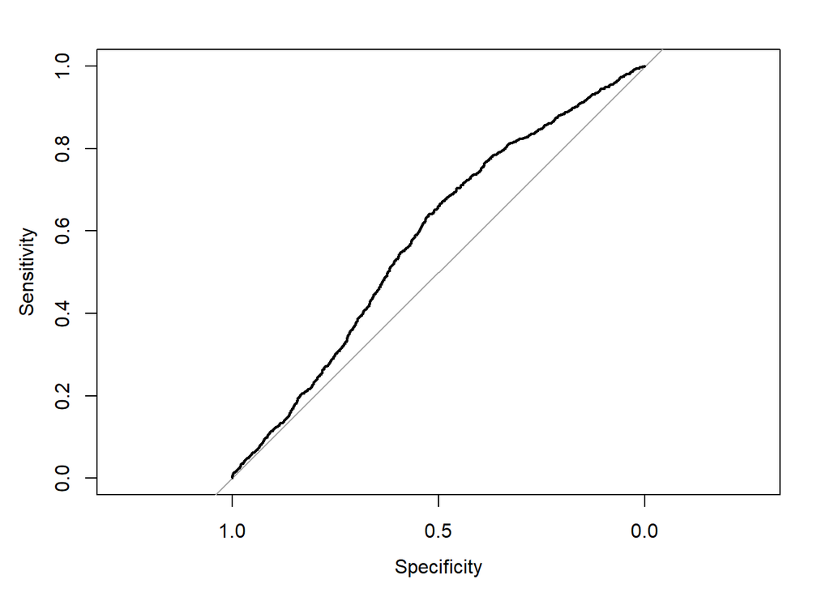

```r
loadPkg("pROC")
prob_SM3 = predict(churnLogit_SM3, type = "response" )
churn_data_pc_target$prob_SM3 = prob_SM3
h_SM3 <- roc(churn~prob_SM3, data=churn_data_pc_target)
auc(h_SM3)
plot(h_SM3)
```

```r
unloadPkg("pROC")
```

```r
loadPkg("pscl") # use pR2( ) function to calculate McFadden statistics for model eval
churnLogitpr2_SM3 = pR2(churnLogit_SM3)
churnLogitpr2_SM3
unloadPkg("pscl")
```

### What are the principal components for predicting churn rate?

```r
pr.out=prcomp(churn_data_pc, scale =TRUE)
print("Case: z-score/scaled")
summary(pr.out)
pr.out$rotation
```

```r
nrow(train)
prop.table( table(train$churn) )
```

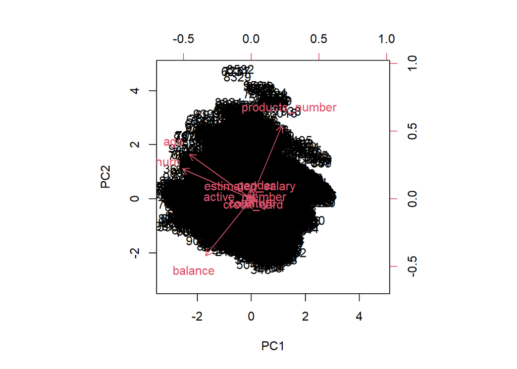

```r
biplot(pr.out, scale = 0)
```

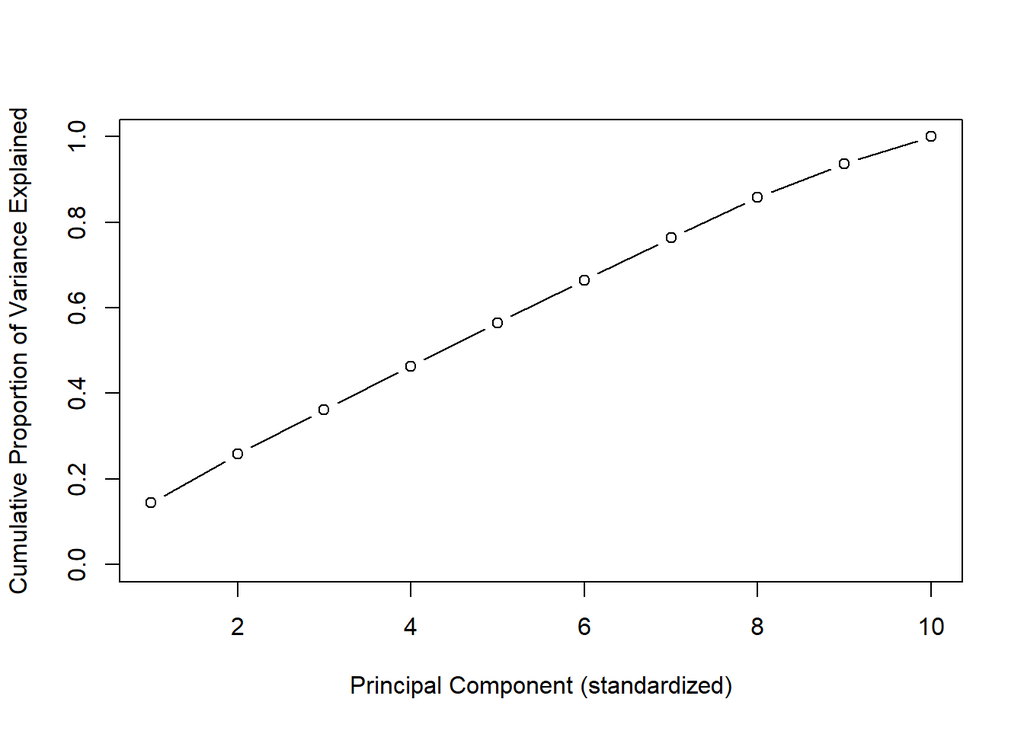

```r
pr.var <- (pr.out$sdev^2)
pve <- pr.var/sum(pr.var)
plot(cumsum(pve), xlab="Principal Component (standardized)", ylab ="Cumulative Proportion of Variance Explained",ylim=c(0,1),type="b")
```

### Which model can give the best results for adjusted R square and ROC value with lower AIC and BIC?

**Feature selection using Exhaustive search**

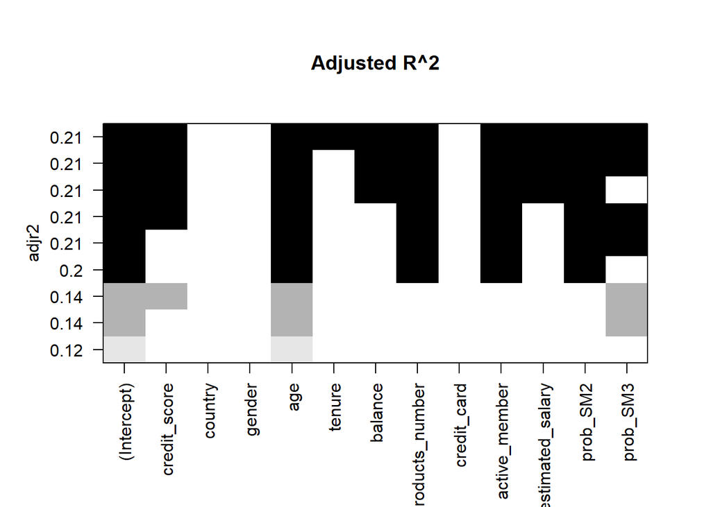

```r
loadPkg("leaps")

reg.churn <- regsubsets(churn~.-prob, data = churn_data_pc_target, nvmax =9, nbest = 1, method = "exhaustive")
plot(reg.churn , scale = "adjr2", main = "Adjusted R^2")
```

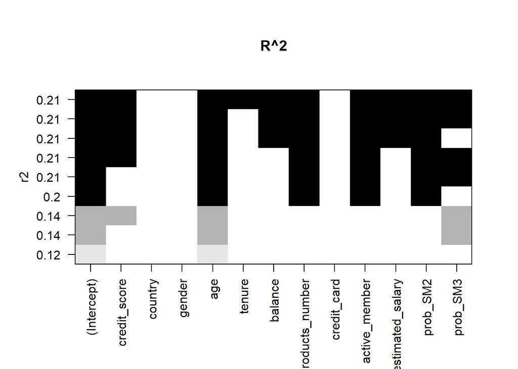

```r
plot(reg.churn , scale = "r2", main = "R^2")
```

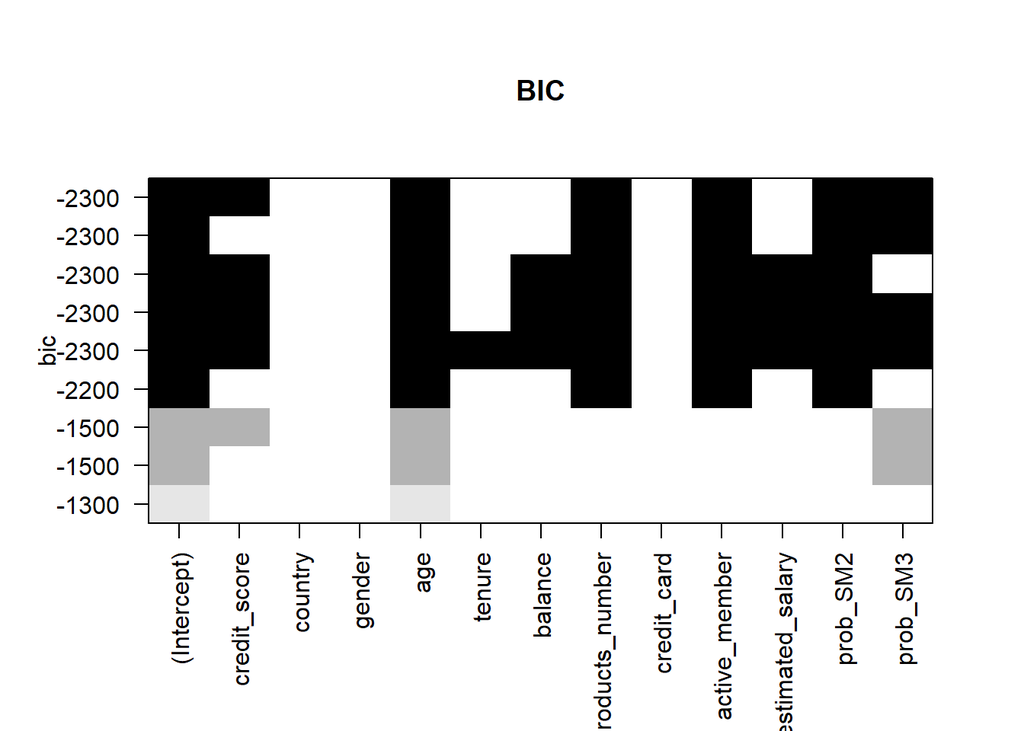

```r
plot(reg.churn , scale = "bic", main = "BIC")
```

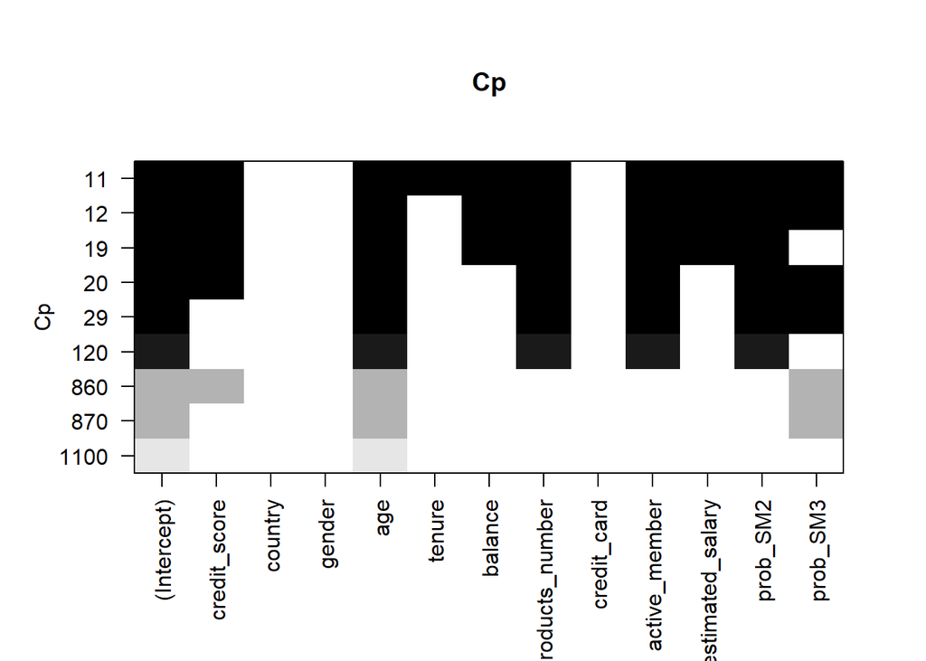

```r
plot(reg.churn , scale = "Cp", main = "Cp")
```

```r
summary(reg.churn )
```

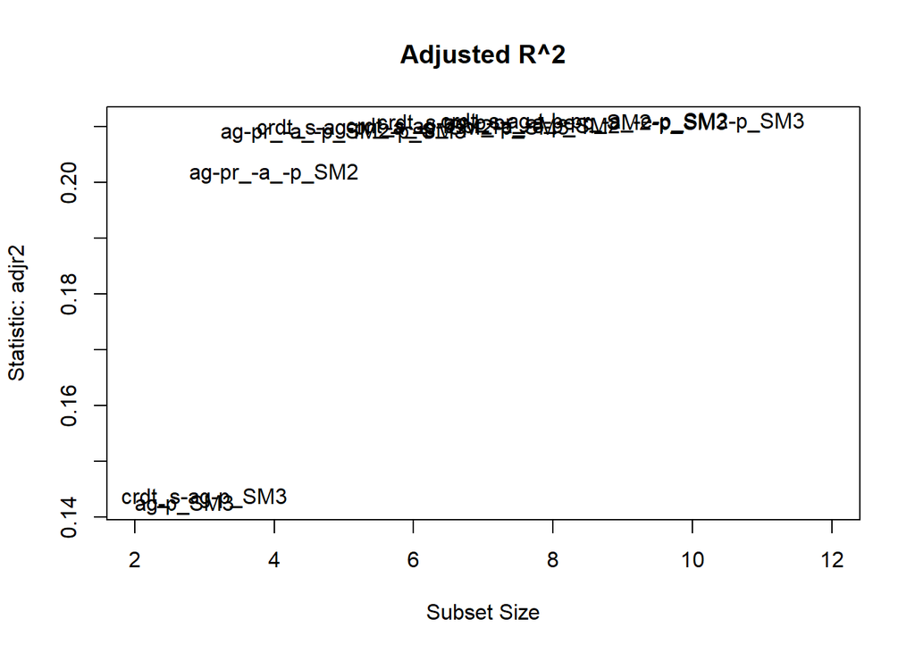

```r
loadPkg("car")

# Adjusted R2
car::subsets(reg.churn, statistic="adjr2", legend = FALSE, min.size = 2, main = "Adjusted R^2")
```

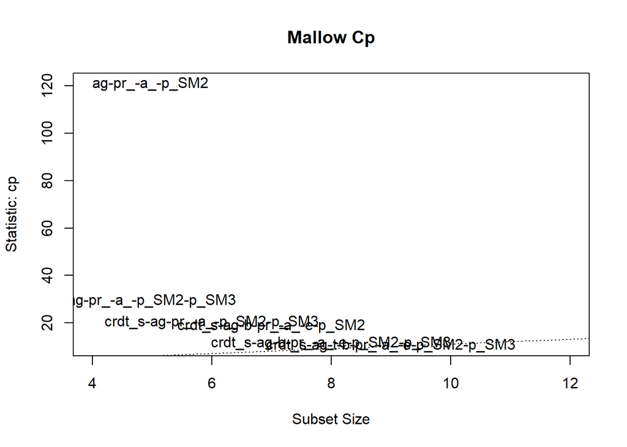

```r
subsets(reg.churn, statistic="cp", legend = FALSE, min.size = 4, main = "Mallow Cp")
abline(a = 1, b = 1, lty = 3)
```